# For the love of coax

2023-03-25 07:55:35

## Agenda

- Choosing coax types
- Making coax patch cables

## Choosing coax

## Considerations

- Power
- Frequency
- Length, location, & use
- Connectors

## Power

- High power vs. low
- QRP

## Frequency

- HF
- VHF
- UHF or higher

## Length, location & use

- Long (e.g., feedline) vs. short (patch)
- Indoors
  - Short radius turns?
- Outdoors
  - Water resistance
  - UV resistance
  - Weight (EFHW vs. dipole)

## Basic principles

- Don’t exceed power handling capacity
- Minimize signal loss (attenuation)
- Minimize cost
- “As short as possible”

## Some data

https://docs.google.com/spreadsheets/d/14FFnRm2fk9u0FUJHsBTqYPRzI6EGs8cr6EH4aVEpFCo/edit?usp=sharing

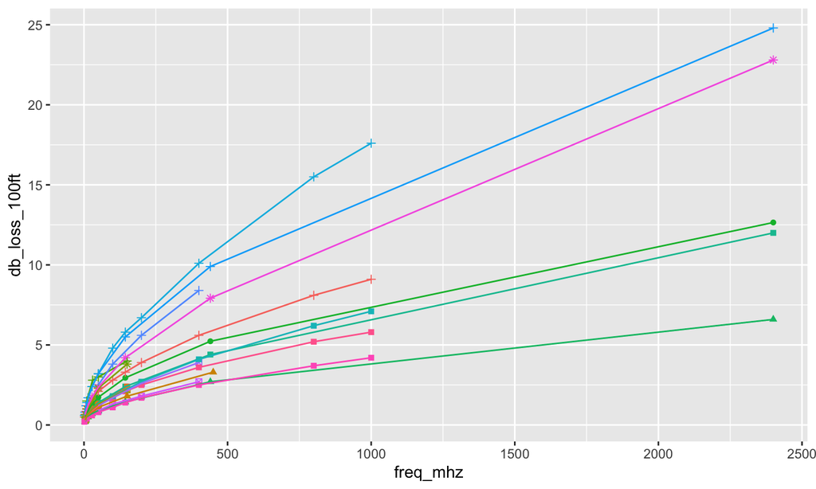

Attenuation (dB/100’) by frequency (HF - UHF)

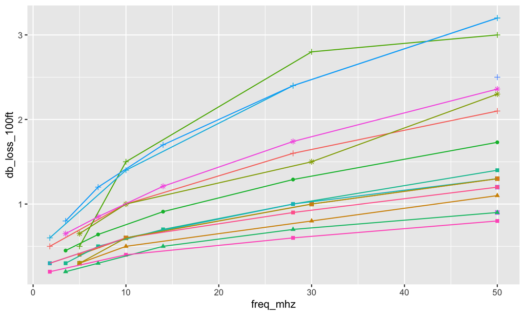

Attenuation (dB/100’) by frequency: HF + 50 MHz

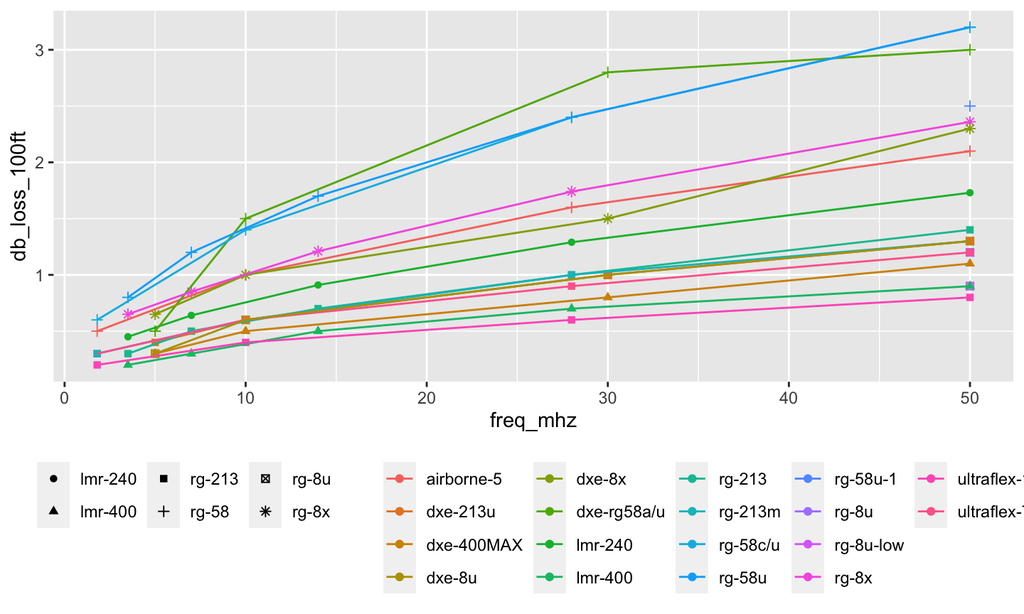

Attenuation (dB/100’) by frequency: HF + 50 MHz

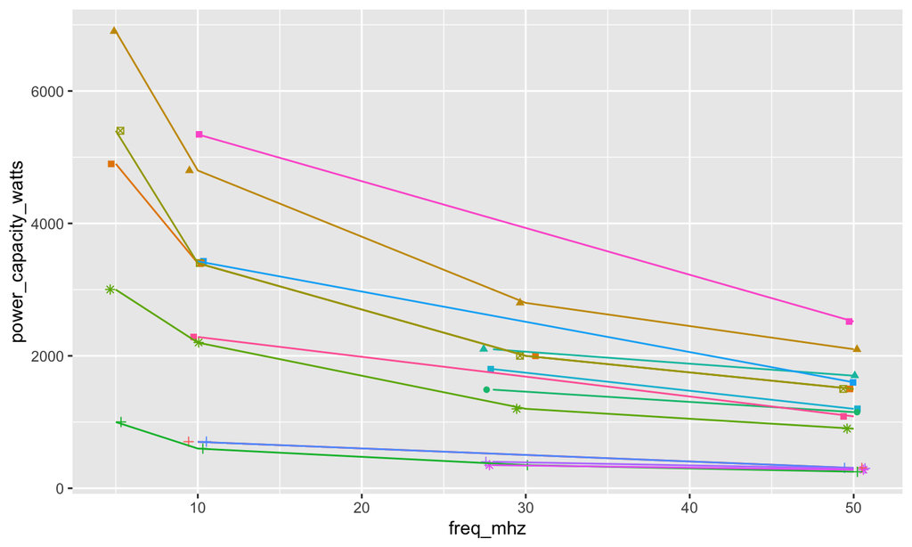

Power capacity by frequency: HF + 50 MHz

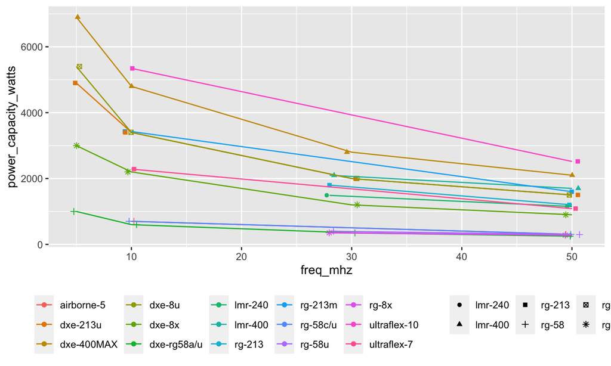

Power capacity by frequency: HF + 50 MHz

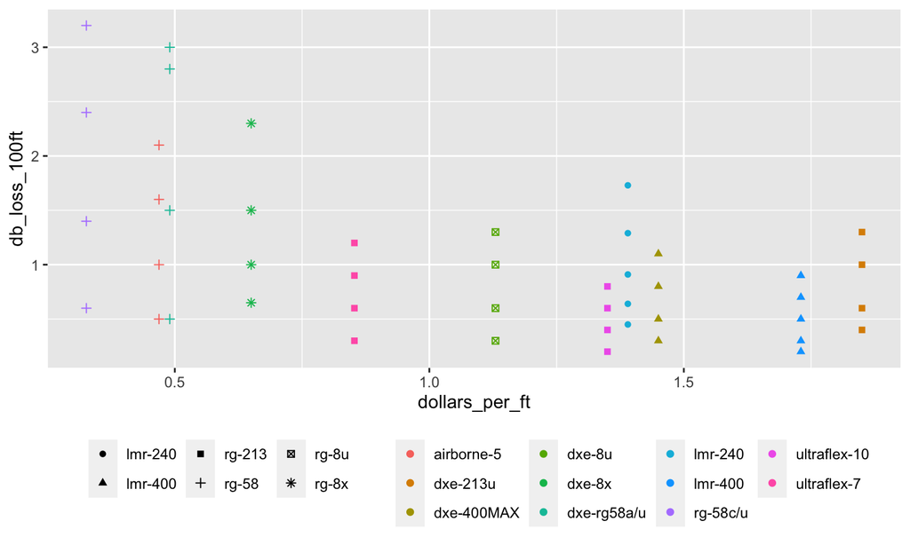

Cost (US$/ft) vs. Attenuation

## Conclusions (HF+ 50 MHz)

- Low power
  - In shack: RG-58 or RG-8X
  - Outside/feedline:
    - Short-runs or dipole centers RG-58 or RG-8X
    - RG-8U/RG-213 with a solid support
- Higher power
  - In shack: RG-8U/RG-213
  - Outside/feedline: RG-8U/RG-213 or LMR-400

## Resources

- https://www.onallbands.com/coaxial-cable-guide-understanding-the-differences-among-types-of-coaxial-cable%EF%BB%BF/
- https://www.qsradio.com/coax-and-connector-info.html
- https://www.universal-radio.com/catalog/cable/coaxperf.html
- https://messi.it/en/comparison-chart-50-ohm-cables.htm
- https://static.dxengineering.com/global/images/chartsguides/d/dxe-400max_ks.pdf
- https://www.hamradioschool.com/post/coaxial-loss-t9b05

## Making patch cables

## What

- Coax
- Connectors (usually 2x male, but YMMV)
  - Specific to **coax type**
  - Specific to **attachment type**: solder vs. crimp/solder
- Crimp tool (if crimping), solder + soldering iron (for both)
- Cutting/prep tool (optional, but handy)
- Side cutters (for trimming braid)
- Heat shrink + heat gun or tape (optional but advised)

## Why?

- Fun
- Learn new skill
- Save $
  - Pre-made: [$28.99 (3’)](https://www.dxengineering.com/parts/dxe-8xdx003) - [$30.49 (6’)](https://www.dxengineering.com/parts/dxe-8xdx006)
  - Pay for tool cost in about 3 cables

## How

[video not shown]

## Shopping list

- Coax
  - RG-8X https://www.dxengineering.com/parts/dxe-8x
- Connectors (PL-259/UHF Male)
  - Crimp/solder type https://www.dxengineering.com/parts/dxe-pl259cs8x-6
  - Solder type
    - Connector https://www.dxengineering.com/parts/dxe-pl259-6
    - RG-8X reducer https://www.dxengineering.com/parts/dxe-ug176s-6/part-type/coaxial-connectors
- Cutting/prep tool
  - Crimp/solder connector type https://www.dxengineering.com/parts/dxe-ut-240c-p1
  - Solder connector type https://www.dxengineering.com/parts/dxe-ut-808x
- Or combo cutting/crimp toolset
  - Deluxe Coax Crimp Kit https://www.qsradio.com/shop-now.html#!/Deluxe-Coax-Crimp-Kit/p/50841245/category=8446815

## Final words

- There’s only one “law” psychologists have proven
  - Fitt’s Law: speed vs. accuracy
- Pay now or pay later